# Likelihood figures

SrenBlikdal

2026-06-30

# Setup and configuration

## Packages

```r
library(bsseq)
library(tidyverse)
library(rtracklayer)
library(GenomicRanges)
library(patchwork)
library(gghalves)
library(RColorBrewer)
```

## Paths and global options

```r
# Project-relative paths (recommended)
data_dir <- "data"
truth_dir <- file.path(data_dir, "truthset")
meth_dir  <- file.path(data_dir, "bedMethyls")

# Truthset files (edit as needed)
vcf_path <- file.path(truth_dir, "HG002_GRCh38_1_22_v4.2.1_benchmark_chr1.vcf")
hc_bed   <- file.path(truth_dir, "HG002_GRCh38_1_22_v4.2.1_benchmark_noinconsistent_chr1.bed")

ref_cg_bed <- file.path(truth_dir, "GCF_000001405.40_GRCh38.p14_genomic_CG_chr1.bed")
ref_ch_bed <- file.path(truth_dir, "GCF_000001405.40_GRCh38.p14_genomic_CH_chr1.bed")
ref_cg_silver_bed <- file.path(truth_dir, "Mmenidia_refgenome_anchored.all_renamed_v2_CG_ch24.bed")

# Input methylation files
nano_file <- file.path(meth_dir, "HG002_nanopore_chr1.bedMethyl.gz")
pacbio_file <- file.path(meth_dir, "HG002_pacbio_chr1.bedMethyl.gz")
silver_files <- list.files(meth_dir, pattern = "bedmethyl")
silver_paths <- file.path(meth_dir,silver_files)
```

## Helper functions

```r
count_overlaps <- function(query_gr, targets) {
  c(
    length(subsetByOverlaps(query_gr, targets$ref_hom_CG, ignore.strand = TRUE)),
    length(subsetByOverlaps(query_gr, targets$ref_het_CG, ignore.strand = TRUE)),
    length(subsetByOverlaps(query_gr, targets$ref_non_CG, ignore.strand = TRUE)),
    length(subsetByOverlaps(query_gr, targets$ref_CH_hom, ignore.strand = TRUE)),
    length(subsetByOverlaps(query_gr, targets$ref_CH_het, ignore.strand = TRUE)),
    length(subsetByOverlaps(query_gr, targets$ref_CH_non, ignore.strand = TRUE))
  )
}

build_conf_mat <- function(mc, targets) {
  tot <- sapply(targets, length)
  raw <- count_overlaps(granges(mc), targets)
  all <- count_overlaps(granges(mc[getCpGs(mc, type = "allCpG"), ]), targets)
  hom <- count_overlaps(granges(mc[getCpGs(mc, type = "homozygous"), ]), targets)
  het <- count_overlaps(granges(mc[getCpGs(mc, type = "heterozygous"), ]), targets)

  conf_mat <- rbind(tot, raw, all, hom, het)
  rownames(conf_mat) <- c("benchmark loci", "unfiltered", "allCpG", "homozygous", "heterozygous")
  colnames(conf_mat) <- c(
    "ref_homozygous", "ref_heterozygous", "ref_non-CpG",
    "homozygous", "heterozygous", "non-CpG"
  )
  conf_mat
}

plot_conf_mat <- function(conf_mat, title = NULL) {
  conf_mat_freq <- sweep(conf_mat[2:5, ], 2, conf_mat[1, ], "/")

  conf_mat_freq_tbl <- as_tibble(conf_mat_freq, rownames = "Call") %>%
    pivot_longer(-Call, names_to = "Truth", values_to = "freq")

  conf_mat_count_tbl <- as_tibble(conf_mat, rownames = "Call") %>%
    pivot_longer(-Call, names_to = "Truth", values_to = "n")

  conf_mat_plot <- left_join(conf_mat_count_tbl, conf_mat_freq_tbl, by = c("Truth", "Call")) %>%
    mutate(freq = ifelse(Truth %in% c("ref_non-CpG", "non-CpG"), 1 - freq, freq))

  truth_levels <- c("ref_homozygous", "ref_heterozygous", "ref_non-CpG", "homozygous", "heterozygous", "non-CpG")
  call_levels  <- c("benchmark loci", "unfiltered", "allCpG", "homozygous", "heterozygous")

  conf_mat_plot$Call  <- factor(conf_mat_plot$Call, levels = rev(call_levels))
  conf_mat_plot$Truth <- factor(conf_mat_plot$Truth, levels = truth_levels)

  ggplot(conf_mat_plot, aes(x = Truth, y = Call, fill = freq)) +
    geom_tile() +
    geom_text(aes(label = n, color = ifelse(is.na(freq), "white", ifelse(freq < 0.5, "black", "white")))) +
    scale_color_identity() +
    scale_fill_gradientn(colors = brewer.pal(9, "Reds"), limits = c(0, 1)) +
    scale_x_discrete(labels = function(x) gsub("^ref_", "", x)) +
    geom_vline(xintercept = 3.5, color = "white", size = 2) +
    geom_hline(yintercept = 3.5, color = "white", size = 1) +
    geom_hline(yintercept = 4.5, color = "white", size = 1) +
    labs(title = title, x = "True CpG status", y = "Called CpG status") +
    theme_minimal()
}

make_metrics_table <- function(conf_mat) {
  sens_mat <- sweep(conf_mat[2:5, ], 2, conf_mat[1, ], "/")
  sens_mat[, c("ref_non-CpG", "non-CpG")] <- 1 - sens_mat[, c("ref_non-CpG", "non-CpG")]

  conf_sub <- conf_mat[2:5, ]
  ref_total    <- conf_sub[, 1] + conf_sub[, 2] + conf_sub[, 3]
  nonref_total <- conf_sub[, 4] + conf_sub[, 5] + conf_sub[, 6]
  row_total    <- rowSums(conf_sub)

  ppv_ref <- c(
    (conf_sub["unfiltered", 1] + conf_sub["unfiltered", 2]) / ref_total["unfiltered"],
    (conf_sub["allCpG", 1] + conf_sub["allCpG", 2]) / ref_total["allCpG"],
    conf_sub["homozygous", 1] / ref_total["homozygous"],
    conf_sub["heterozygous", 2] / ref_total["heterozygous"]
  )

  ppv_nonref <- c(
    (conf_sub["unfiltered", 4] + conf_sub["unfiltered", 5]) / nonref_total["unfiltered"],
    (conf_sub["allCpG", 4] + conf_sub["allCpG", 5]) / nonref_total["allCpG"],
    conf_sub["homozygous", 4] / nonref_total["homozygous"],
    conf_sub["heterozygous", 5] / nonref_total["heterozygous"]
  )

  ppv_combined <- c(
    (conf_sub["unfiltered", 1] + conf_sub["unfiltered", 2] + conf_sub["unfiltered", 4] + conf_sub["unfiltered", 5]) / row_total["unfiltered"],
    (conf_sub["allCpG", 1] + conf_sub["allCpG", 2] + conf_sub["allCpG", 4] + conf_sub["allCpG", 5]) / row_total["allCpG"],
    (conf_sub["homozygous", 1] + conf_sub["homozygous", 4]) / row_total["homozygous"],
    (conf_sub["heterozygous", 2] + conf_sub["heterozygous", 5]) / row_total["heterozygous"]
  )

  as.data.frame(sens_mat) %>%
    rownames_to_column("Call") %>%
    mutate(ppv_ref = ppv_ref, ppv_nonref = ppv_nonref, ppv_combined = ppv_combined) %>%
    rename(
      ref_hom = ref_homozygous, ref_het = ref_heterozygous, ref_nonCpG = `ref_non-CpG`,
      nonref_hom = homozygous, nonref_het = heterozygous, nonref_nonCpG = `non-CpG`
    )
}

make_mod_plot <- function(mc, ref_set, nonref_set, title = NULL) {

  # Extract modification levels
  get_mod <- function(x) {
    (getMethylCounts(x, "M") + getMethylCounts(x, "H")) /
      getMethylCounts(x, "Cov")
  }

  ref_mod <- get_mod(
    subsetByOverlaps(mc, ref_set, ignore.strand = TRUE)
  )

  nonref_mod <- get_mod(
    subsetByOverlaps(mc, nonref_set, ignore.strand = TRUE)
  )

  # Data frame
  mod_df <- tibble(
    mod = c(ref_mod, nonref_mod),
    type = rep(c("reference", "non-reference"),
               c(length(ref_mod), length(nonref_mod)))
  )

  # Means
  means <- mod_df |>
    dplyr::summarise(mean_val = mean(mod, na.rm = TRUE),
                     .by = type)

  # KS test
  ks <- ks.test(ref_mod, nonref_mod)

  ks_label <- sprintf(
    "KS = %.3f\np = %.1e",
    ks$statistic,
    ks$p.value
  )

  ggplot() +
    geom_half_violin(
      data = dplyr::filter(mod_df, type == "reference"),
      aes(y = mod, fill = type),
      side = "l",
      adjust = 3
    ) +
    geom_half_violin(
      data = dplyr::filter(mod_df, type == "non-reference"),
      aes(y = mod, fill = type),
      side = "r",
      adjust = 3
    ) +
    geom_segment(
      data = means,
      aes(
        x = ifelse(type == "reference", -0.3, 0.0),
        xend = ifelse(type == "reference", 0.0, 0.3),
        y = mean_val,
        yend = mean_val
      ),
      linewidth = 1
    ) +
    annotate(
      "text",
      x = 0.38,
      y = min(mod_df$mod, na.rm = TRUE) +
        0.05 * diff(range(mod_df$mod, na.rm = TRUE)),
      label = ks_label,
      hjust = 1,
      vjust = 0
    ) +
    scale_fill_manual(
      values = c(
        "reference" = "darkgrey",
        "non-reference" = "lightgrey"
      )
    ) +
    labs(title = title, x = NULL, y = "Modification level") +
    theme_bw()
}
```

# Download and construct HG002 truth set

## Download notes

```r
#import the vcf file
vcf<-read_tsv(
    vcf_path,
    comment = "#",
    col_names = FALSE)
colnames(vcf)<-c(
    "ch","start","X","ref","alt","Y","Z","info", "tag", "tag_info")
vcf$ch<-gsub("chr1","NC_000001.11",vcf$ch)

chr1_gr <- import(
    hc_bed,
    format = "BED")
seqlevels(chr1_gr) <- gsub("chr1","NC_000001.11", seqlevels(chr1_gr))

ref_CG <- import(ref_cg_bed, format = "BED")
ref_CG <- subsetByOverlaps(ref_CG, chr1_gr, ignore.strand = T, type = "any")
ref_CG <- ref_CG[strand(ref_CG) == "+"]

ref_CH <- import(ref_ch_bed, format = "BED")
ref_CH <- subsetByOverlaps(ref_CH, chr1_gr, ignore.strand = T, type = "any")

ref_CH_plus  <- ref_CH[strand(ref_CH) == "+"]
ref_CH_minus <- ref_CH[strand(ref_CH) == "-"]
```

### True homozygous reference CpG sites

Generate a truth set of homozygous reference CpG sites from reference CpG sites that do not overlap variants in the vcf file.

```r
# find CpG sites that do not overlap with any variants in the vcf file
vcf_gr<-GRanges(
    seqnames = vcf$ch,
    ranges = IRanges(start = vcf$start-1, end = vcf$start+nchar(vcf$ref)+1))

ref_hom_CG<-subsetByOverlaps(
    ref_CG, vcf_gr, ignore.strand = T, invert = T, type = "any")
```

#### Remove neighbouring variants

We remove the variants where the neighboring position are also a variant as these neighboring variants can revert heterozygous CpG to homozygous CpG etc.

```r
vcf$next_pos <- c(vcf$start[-1], NA)
vcf$prev_pos <- c(NA, vcf$start[-nrow(vcf)])

# Identify rows with neighboring variants
neighbor_idx <- which(
  vcf$next_pos == vcf$start + 1 |
  vcf$prev_pos == vcf$start - 1
)

# Remove those rows
vcf_no_neighbours <- vcf[-neighbor_idx, ]
```

### True heterozygous reference CpG sites

We generate a truth set of heterozygous reference CpG sites by finding reference CpG sites that overlap heterozygous D > G or C > H variants in the vcf file.

```r
# Filter heterozygous variants (0/1 or 1/0),
# with C or G as reference and single-base ALT
vcf_het <- vcf_no_neighbours %>%
  filter(grepl("0/1|1/0", tag_info)) %>%
  filter(ref == "C" | ref == "G") %>%
  filter(nchar(alt) == 1)

# Adjust start for G reference alleles
vcf_het$start <- ifelse(
  vcf_het$ref == "G",
  vcf_het$start - 1,
  vcf_het$start
)

# Create GRanges object
vcf_het_gr <- GRanges(
  seqnames = vcf_het$ch,
  ranges = IRanges(
    start = vcf_het$start,
    end = vcf_het$start
  )
)

# Find overlaps with reference CpG sites
ref_het_CG <- subsetByOverlaps(
  ref_CG,
  vcf_het_gr,
  ignore.strand = TRUE,
  invert = FALSE,
  type = "any"
)
```

### True reference non-CpG sites

```r
# Filter homozygous variants (1/1),
# with C or G as reference and single-base ALT
vcf_non <- vcf_no_neighbours %>%
  filter(grepl("1/1", tag_info)) %>%
  filter(ref %in% c("C", "G")) %>%
  filter(nchar(alt) == 1)

# Adjust start position for G reference alleles
vcf_non$start <- ifelse(
  vcf_non$ref == "G",
  vcf_non$start - 1,
  vcf_non$start
)

# Create GRanges object
vcf_non_gr <- GRanges(
  seqnames = vcf_non$ch,
  ranges = IRanges(
    start = vcf_non$start,
    end = vcf_non$start
  )
)

# Find overlaps with reference CpG sites
ref_non_CG <- subsetByOverlaps(
  ref_CG,
  vcf_non_gr,
  ignore.strand = TRUE,
  invert = FALSE,
  type = "any"
)
```

### True homozygous non-reference CG loci

Generate a truth set of homozygous non-reference CpG sites by finding reference CH or DG sites that overlap homozygous D > G or C > H variants in the vcf file.

```r
# PLUS STRAND: Homozygous H → G
vcf_hom_G <- vcf_no_neighbours %>%
  filter(grepl("1/1", tag_info)) %>%
  filter(ref != "G" & alt == "G") %>%
  filter(nchar(ref) == 1 & nchar(alt) == 1)

vcf_G_gr <- GRanges(
  seqnames = vcf_hom_G$ch,
  ranges = IRanges(
    start = vcf_hom_G$start - 1,
    end   = vcf_hom_G$start - 1
  )
)

vcf_CH_G <- subsetByOverlaps(
  ref_CH_plus,
  vcf_G_gr,
  ignore.strand = TRUE,
  invert = FALSE,
  type = "any"
)

# MINUS STRAND: Homozygous H → C

vcf_hom_C <- vcf_no_neighbours %>%
  filter(grepl("1/1", tag_info)) %>%
  filter(ref != "C" & alt == "C") %>%
  filter(nchar(ref) == 1 & nchar(alt) == 1)

vcf_C_gr <- GRanges(
  seqnames = vcf_hom_C$ch,
  ranges = IRanges(
    start = vcf_hom_C$start + 1,
    end   = vcf_hom_C$start + 1
  )
)

vcf_CH_C <- subsetByOverlaps(
  ref_CH_minus,
  vcf_C_gr,
  ignore.strand = TRUE,
  invert = FALSE,
  type = "any"
)

# Shift minus strand coordinates
vcf_CH_C <- shift(vcf_CH_C, -1)

# Combine results
ref_CH_hom <- c(vcf_CH_G, vcf_CH_C)
```

### True heterozygous non-reference CG loci

Generate a truth set of heterozygous non-reference CpG sites by finding reference CH or DG sites that overlap heterozygous D > G or C > H variants in the vcf file.

```r
# PLUS STRAND: Heterozygous H → G
vcf_het_G <- vcf_no_neighbours %>%
  filter(grepl("0/1|1/0", tag_info)) %>%
  filter(ref != "G" & alt == "G") %>%
  filter(nchar(ref) == 1, nchar(alt) == 1)

vcf_G_gr <- GRanges(
  seqnames = vcf_het_G$ch,
  ranges = IRanges(
    start = vcf_het_G$start - 1,
    end   = vcf_het_G$start - 1
  )
)

vcf_CH_G <- subsetByOverlaps(
  ref_CH_plus,
  vcf_G_gr,
  ignore.strand = TRUE,
  invert = FALSE,
  type = "any"
)

# MINUS STRAND: Heterozygous H → C
vcf_het_C <- vcf_no_neighbours %>%
  filter(grepl("0/1|1/0", tag_info)) %>%
  filter(ref != "C" & alt == "C") %>%
  filter(nchar(ref) == 1, nchar(alt) == 1)

vcf_C_gr <- GRanges(
  seqnames = vcf_het_C$ch,
  ranges = IRanges(
    start = vcf_het_C$start + 1,
    end   = vcf_het_C$start + 1
  )
)

vcf_CH_C <- subsetByOverlaps(
  ref_CH_minus,
  vcf_C_gr,
  ignore.strand = TRUE,
  invert = FALSE,
  type = "any"
)

# Shift minus strand coordinates
vcf_CH_C <- shift(vcf_CH_C, -1)

# Combine results
ref_CH_het <- c(vcf_CH_G, vcf_CH_C)
```

### True non-reference non-CpG loci

Generate a truth set of non-reference non-CpG sites by finding reference CH or DG sites that do not overlap with any variants in the vcf file.

```r
# Create GRanges object for all variants
vcf_gr <- GRanges(
  seqnames = vcf$ch,
  ranges = IRanges(
    start = vcf$start - 1,
    end   = vcf$start + nchar(vcf$ref) + 1
  )
)

# Find CH sites that do NOT overlap any variants
ref_CH_non <- subsetByOverlaps(
  ref_CH,
  vcf_gr,
  ignore.strand = TRUE,
  invert = TRUE,
  type = "any"
)
```

## Benchmark data

For benchmarking, we use a truth set of 2.083.686 homozygous CpG loci, 26.352 heterozygous CpG loci and 14.805 non-CpG loci in the sample, which are all CpG loci in the reference genome. We also have a truth set of 16.891 homozygous CpG loci and 22.288 heterozygous CpG loci, and 84.991.174 non-CpG loci (CH/DG) in the sample, which are non-CpG loci in the reference genome.

```r
benchmark_data <- tibble(
  reference_CG = c("yes", "yes", "yes", "no", "no", "no"),
  type = c(
    "homozygous", "heterozygous", "non-CpG",
    "homozygous", "heterozygous", "non-CpG"
  ),
  n = c(
    length(ref_hom_CG),
    length(ref_het_CG),
    length(ref_non_CG),
    length(ref_CH_hom),
    length(ref_CH_het),
    length(ref_CH_non)
  )
)

targets <- list(
  ref_hom_CG = ref_hom_CG,
  ref_het_CG = ref_het_CG,
  ref_non_CG = ref_non_CG,
  ref_CH_hom = ref_CH_hom,
  ref_CH_het = ref_CH_het,
  ref_CH_non = ref_CH_non
)

benchmark_data
```

```
## # A tibble: 6 × 3
##   reference_CG type                n
##   <chr>        <chr>           <int>
## 1 yes          homozygous    2083686
## 2 yes          heterozygous    26352
## 3 yes          non-CpG         14805
## 4 no           homozygous      16891
## 5 no           heterozygous    22288
## 6 no           non-CpG      84991174
```

# Nanopore: preprocessing, benchmarking, and modification levels

### Download notes

-GIAB HG002 nanopore source: https://epi2me.nanoporetech.com/giab-2023.05/.  
-Basecall pod5_pass directory of the sequencing run 20230424_1302_3H_PAO89685_2264ba8c using dna_r10.4.1_e8.2_400bps_sup@v4.3.0_5mCG_5hmCG@v1.  
-Map to GRCh38 using minimap2/2.26 and SAMtools/1.20 -Pileup using Modkit/0.4.2 with default settings. -Subset to chr1.

### Read data

```r
mc_nano <- read.bedMethyl(
  nano_file,
  strandCollapse = TRUE,
  verbose = TRUE,
  output = "MethylCounts"
)
```

```
## data/bedMethyls/HG002_nanopore_chr1.bedMethyl.gz
```

### Benchmarking (confusion matrix + figure + table)

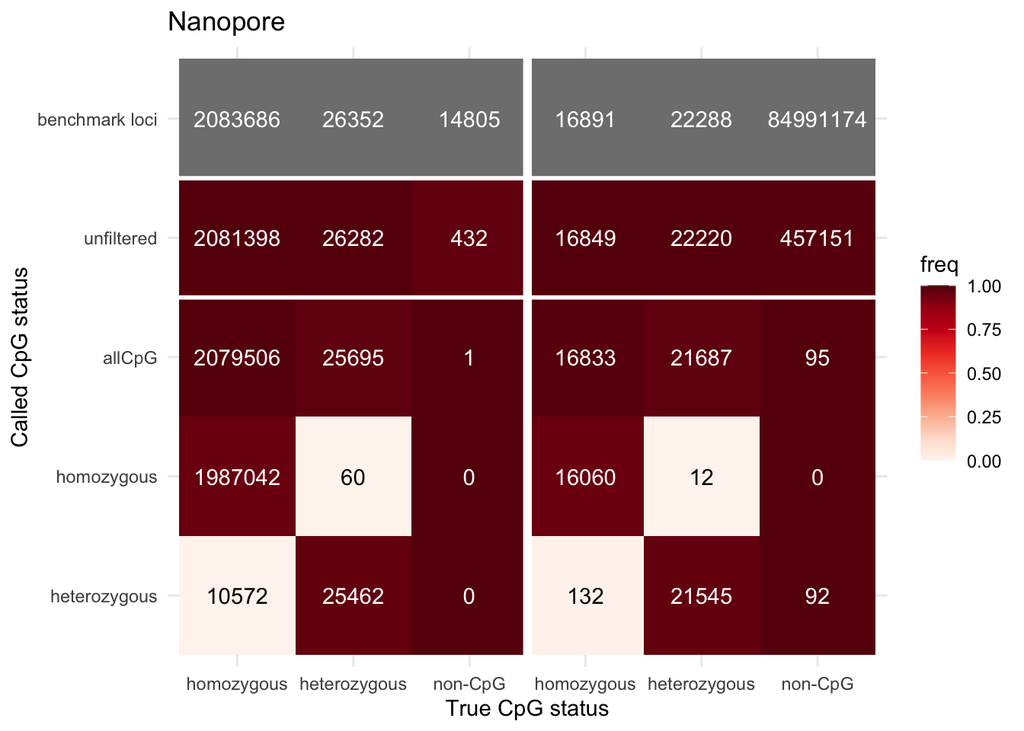

```r
conf_nano <- build_conf_mat(mc_nano, targets)
p_nano_conf <- plot_conf_mat(conf_nano, title = "Nanopore")
p_nano_conf
```

```r
nano_metrics <- make_metrics_table(conf_nano)
nano_metrics_fmt <- nano_metrics %>% mutate(across(-Call, ~ sprintf("%.5f", .)))
nano_metrics_fmt
```

```
##           Call ref_hom ref_het ref_nonCpG nonref_hom nonref_het nonref_nonCpG
## 1   unfiltered 0.99890 0.99734    0.97082    0.99751    0.99695       0.99462
## 2       allCpG 0.99799 0.97507    0.99993    0.99657    0.97303       1.00000
## 3   homozygous 0.95362 0.00228    1.00000    0.95080    0.00054       1.00000
## 4 heterozygous 0.00507 0.96623    1.00000    0.00781    0.96666       1.00000
##   ppv_ref ppv_nonref ppv_combined
## 1 0.99980    0.07873      0.82430
## 2 1.00000    0.99754      0.99996
## 3 0.99997    0.99925      0.99996
## 4 0.70661    0.98971      0.81323
```

### Modification-level plots

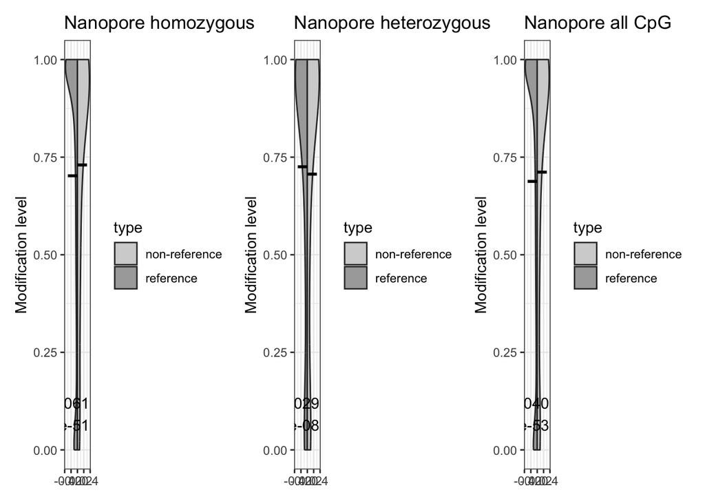

```r
p_nano_hom <- make_mod_plot(mc_nano[getCpGs(mc_nano, type = "homozygous"), ], ref_hom_CG, ref_CH_hom, "Nanopore homozygous")
p_nano_het <- make_mod_plot(mc_nano[getCpGs(mc_nano, type = "heterozygous"), ], ref_het_CG, ref_CH_het, "Nanopore heterozygous")
p_nano_all <- make_mod_plot(mc_nano[getCpGs(mc_nano, type = "allCpG"), ], c(ref_hom_CG, ref_het_CG), c(ref_CH_hom, ref_CH_het), "Nanopore all CpG")

p_nano_hom + p_nano_het + p_nano_all
```

# PacBio: preprocessing, benchmarking, and modification levels

### Download notes

-GIAB HG002 PacBio source: https://doi.org/https://downloads.pacbcloud.com/public/2024Q4/Vega/HG002/.  
-Map to GRCh38 using minimap2/2.26 and SAMtools/1.20.  
-Pileup using Modkit/0.4.2 with –no-filtering.

### Read data

```r
mc_pac <- read.bedMethyl(
  pacbio_file,
  strandCollapse = TRUE,
  verbose = TRUE,
  output = "MethylCounts"
)
```

```
## data/bedMethyls/HG002_pacbio_chr1.bedMethyl.gz
```

### Benchmarking (confusion matrix + figure + table)

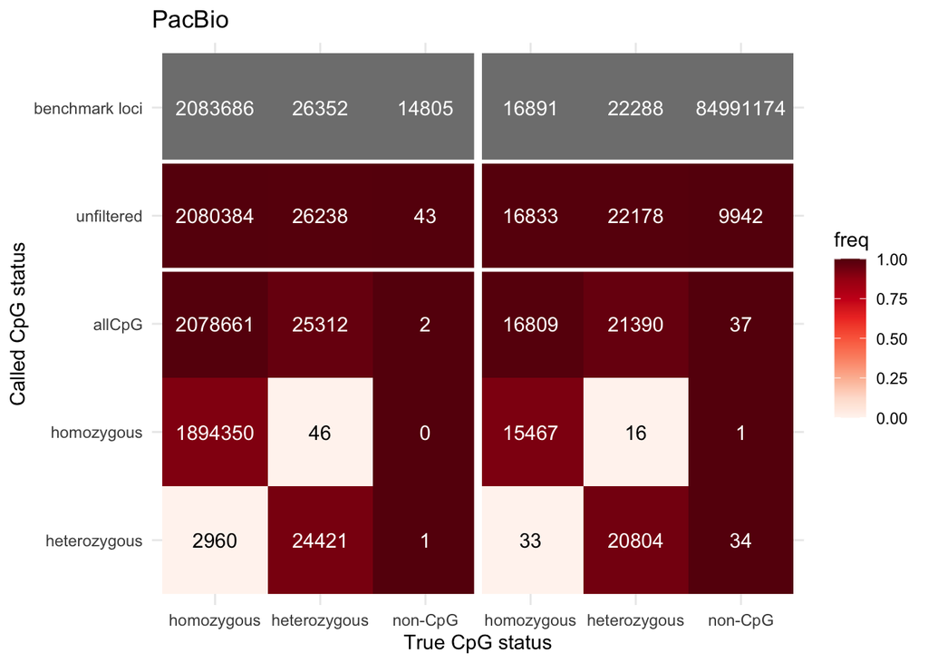

```r
conf_pac <- build_conf_mat(mc_pac, targets)
p_pac_conf <- plot_conf_mat(conf_pac, title = "PacBio")
p_pac_conf
```

```r
pac_metrics <- make_metrics_table(conf_pac)
pac_metrics_fmt <- pac_metrics %>% mutate(across(-Call, ~ sprintf("%.5f", .)))
pac_metrics_fmt
```

```
##           Call ref_hom ref_het ref_nonCpG nonref_hom nonref_het nonref_nonCpG
## 1   unfiltered 0.99842 0.99567    0.99710    0.99657    0.99506       0.99988
## 2       allCpG 0.99759 0.96053    0.99986    0.99515    0.95971       1.00000
## 3   homozygous 0.90913 0.00175    1.00000    0.91569    0.00072       1.00000
## 4 heterozygous 0.00142 0.92672    0.99993    0.00195    0.93342       1.00000
##   ppv_ref ppv_nonref ppv_combined
## 1 0.99998    0.79691      0.99537
## 2 1.00000    0.99903      0.99998
## 3 0.99998    0.99890      0.99997
## 4 0.89186    0.99679      0.93725
```

### Modification-level plots

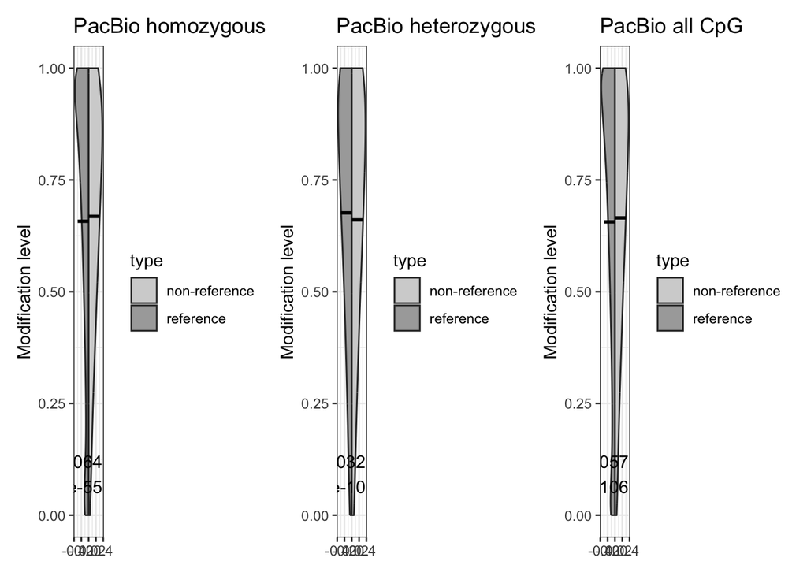

```r
p_pac_hom <- make_mod_plot(mc_pac[getCpGs(mc_pac, type = "homozygous"), ], ref_hom_CG, ref_CH_hom, "PacBio homozygous")
p_pac_het <- make_mod_plot(mc_pac[getCpGs(mc_pac, type = "heterozygous"), ], ref_het_CG, ref_CH_het, "PacBio heterozygous")
p_pac_all <- make_mod_plot(mc_pac[getCpGs(mc_pac, type = "allCpG"), ], c(ref_hom_CG, ref_het_CG), c(ref_CH_hom, ref_CH_het), "PacBio all CpG")
p_pac_hom + p_pac_het + p_pac_all
```

# Silversides: preprocessing, validation, and modification levels

### Download notes

-European Nucleotide Archive (ENA) under the Study Accession PRJEB86757  
-Basecalled BAM using dna_r10.4.1_e8.2_400bps_sup@- v4.3.0_5mCG_5hmCG@v1.  
-Map to Silverside genome using minimap2/2.26 and SAMtools/1.20 -Pileup using Modkit/0.4.2 with default settings. -Subset to chr24.

### Read data

```r
# Expected objects from setup section:
# - silver_paths: character vector of 9 bedMethyl files
# - ref_cg_silver_bed: BED file of reference CpG loci for silversides

mc_silver_raw <- read.bedMethyl(
  silver_paths,
  strandCollapse = TRUE,
  verbose = TRUE,
  output = "MethylCounts"
)
```

```
## data/bedMethyls/NN1854_ch24.bedmethyl
## data/bedMethyls/NN1867_ch24.bedmethyl
## data/bedMethyls/NN1870_ch24.bedmethyl
## data/bedMethyls/NS1841_ch24.bedmethyl
## data/bedMethyls/NS1860_ch24.bedmethyl
## data/bedMethyls/NS1872_ch24.bedmethyl
## data/bedMethyls/SS1849_ch24.bedmethyl
## data/bedMethyls/SS1871_ch24.bedmethyl
## data/bedMethyls/SS1881_ch24.bedmethyl
```

```r
G_all<-getCpGMatrix(mc_silver_raw, allCpG = T)
Q_all<-getMaxLikelihoodMatrix(mc_silver_raw, allCpG = T)

loci.idx <- which(DelayedMatrixStats::rowSums2(Q_all >= .99 & G_all==0) >= 2)
mc_silver<-mc_silver_raw[loci.idx]
```

### Read reference CG loci and convert to GRanges

```r
ref_CG_silver <- import(ref_cg_silver_bed)
ref_CG_silver <- ref_CG_silver[strand(ref_CG_silver) == "+"]

ref_CG_silver_gr <- GRanges(
  seqnames = seqnames(ref_CG_silver),
  ranges = IRanges(
    start = start(ref_CG_silver)-1,
    end = start(ref_CG_silver)))
```

### Build Silversides summary matrix (counts + frequencies)

```r
count_coverage <- function(mc_obj) {
  sapply(seq_len(ncol(mc_obj)), function(i) {
    sum(getMethylCounts(mc_obj[, i], type = "Cov") >= 1)
  })
}

count_overlaps_mc <- function(mc_obj, cpg_type, ref_gr, invert = FALSE) {
  sapply(seq_len(ncol(mc_obj)), function(i) {
    gr_i <- granges(mc_obj[, i][getCpGs(mc_obj[, i], type = cpg_type), ])
    length(subsetByOverlaps(gr_i, ref_gr, ignore.strand = TRUE, type = "any", invert = invert))
  })
}

unfiltered <- count_coverage(mc_silver_raw)

all_ref <- count_overlaps_mc(mc_silver, "allCpG", ref_CG_silver_gr)
hom_ref <- count_overlaps_mc(mc_silver, "homozygous", ref_CG_silver_gr)
het_ref <- count_overlaps_mc(mc_silver, "heterozygous", ref_CG_silver_gr)

all_nonref <- count_overlaps_mc(mc_silver, "allCpG", ref_CG_silver_gr, invert = TRUE)
hom_nonref <- count_overlaps_mc(mc_silver, "homozygous", ref_CG_silver_gr, invert = TRUE)
het_nonref <- count_overlaps_mc(mc_silver, "heterozygous", ref_CG_silver_gr, invert = TRUE)

conf_silver <- matrix(
  c(unfiltered, hom_ref, het_ref, all_ref, hom_nonref, het_nonref, all_nonref),
  ncol = 7,
  byrow = FALSE
)

rownames(conf_silver) <- c("AA1","AA2","AA3","RA1","RA2","RA3","RR1","RR2","RR3")
colnames(conf_silver) <- c(
  "unfiltered",
  "ref_homozygous", "ref_heterozygous", "ref_allCpG",
  "homozygous", "heterozygous", "allCpG"
)

conf_silver
```

```
##     unfiltered ref_homozygous ref_heterozygous ref_allCpG homozygous
## AA1     439347         247833            26156     297049      24675
## AA2     490307         261663            28643     299892      26437
## AA3     447940         247287            24084     299865      24087
## RA1     476150         251411            46120     318445       8720
## RA2     464227         248470            45092     317641       8589
## RA3     466654         251081            47422     316125       8626
## RR1     475588         275048            28663     320606       9511
## RR2     470041         271562            29164     319686       9220
## RR3     473872         275008            29106     319934       9254
##     heterozygous allCpG
## AA1        17870  46389
## AA2        20917  49206
## AA3        16188  45090
## RA1        38651  50054
## RA2        33892  44987
## RA3        38634  49453
## RR1        18854  30430
## RR2        19484  30998
## RR3        17217  28220
```

### Plot Silversides heatmap (counts + frequencies)

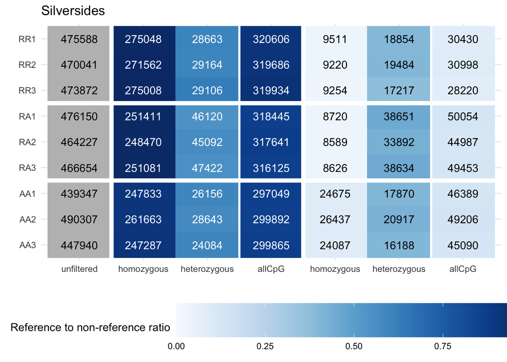

```r
silver_counts_tbl <- as_tibble(conf_silver, rownames = "sample") %>%
  pivot_longer(-sample, names_to = "Call", values_to = "n")

silver_freq <- cbind(
  ref_homozygous   = conf_silver[, "ref_homozygous"]   / (conf_silver[, "ref_homozygous"]   + conf_silver[, "homozygous"]),
  ref_heterozygous = conf_silver[, "ref_heterozygous"] / (conf_silver[, "ref_heterozygous"] + conf_silver[, "heterozygous"]),
  ref_allCpG       = conf_silver[, "ref_allCpG"]       / (conf_silver[, "ref_allCpG"]       + conf_silver[, "allCpG"]),
  homozygous       = conf_silver[, "homozygous"]       / (conf_silver[, "ref_homozygous"]   + conf_silver[, "homozygous"]),
  heterozygous     = conf_silver[, "heterozygous"]     / (conf_silver[, "ref_heterozygous"] + conf_silver[, "heterozygous"]),
  allCpG           = conf_silver[, "allCpG"]           / (conf_silver[, "ref_allCpG"]       + conf_silver[, "allCpG"])
)

rownames(silver_freq) <- rownames(conf_silver)
silver_freq_tbl <- as_tibble(silver_freq, rownames = "sample") %>%
  pivot_longer(-sample, names_to = "Call", values_to = "freq")

silver_plot_tbl <- left_join(silver_counts_tbl, silver_freq_tbl, by = c("sample", "Call"))
silver_plot_tbl$freq[silver_plot_tbl$Call == "unfiltered"] <- NA

call_levels <- c("unfiltered", "ref_homozygous", "ref_heterozygous", "ref_allCpG", "homozygous", "heterozygous", "allCpG")
sample_levels <- rev(c("RR1","RR2","RR3","RA1","RA2","RA3","AA1","AA2","AA3"))

silver_plot_tbl$Call <- factor(silver_plot_tbl$Call, levels = call_levels)
silver_plot_tbl$sample <- factor(silver_plot_tbl$sample, levels = sample_levels)

p_silver_heatmap <- ggplot(silver_plot_tbl, aes(x = Call, y = sample, fill = freq)) +
  geom_tile() +
  geom_text(aes(label = n, color = ifelse(is.na(freq) | freq < 0.5, "black", "white"))) +
  scale_color_identity() +
  scale_fill_gradientn(
    colors = RColorBrewer::brewer.pal(9, "Blues"),
    limits = c(0, 1),
    na.value = "grey"
  ) +
  scale_x_discrete(labels = function(x) gsub("^ref_", "", x)) +
  geom_vline(xintercept = c(1.5, 4.5), color = "white", size = 2) +
  geom_vline(xintercept = c(3.5, 6.5), color = "white", size = 1) +
  geom_hline(yintercept = c(3.5, 6.5), color = "white", size = 2) +
  labs(
    title = "Silversides",
    x = "",
    y = "",
    fill = "Reference to non-reference ratio"
  ) +
  theme_minimal() +
  theme(
    legend.position = "bottom",
    legend.key.height = unit(1.2, "cm"),
    legend.key.width = unit(2.5, "cm")
  )

p_silver_heatmap
```

### Silversides modification-level plots

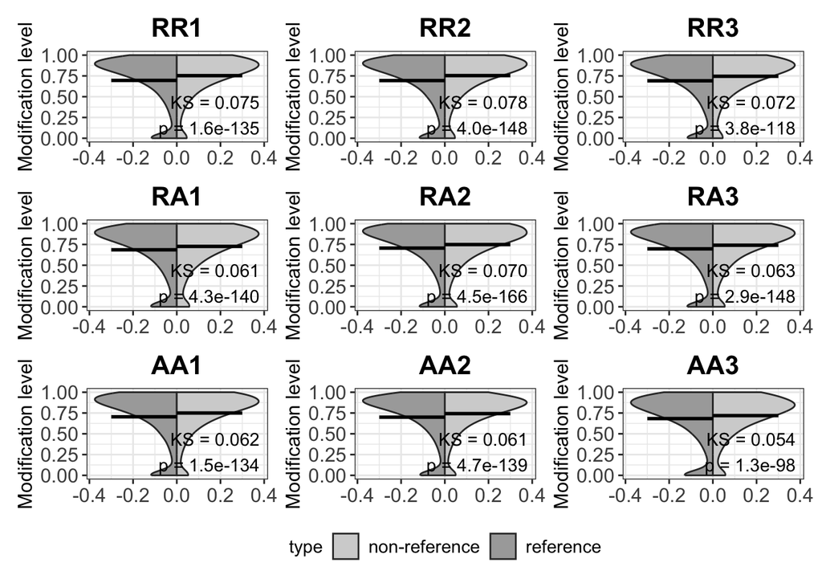

```r
samples <- c("AA1","AA2","AA3","RA1","RA2","RA3","RR1","RR2","RR3")

# Build one plot per sample using shared helper
p_silver_list <- lapply(seq_along(samples), function(i) {
  mc_i <- mc_silver[, i][getCpGs(mc_silver[, i], type = "allCpG"), ]

  make_mod_plot(
    mc = mc_i,
    ref_set = ref_CG_silver_gr,
    nonref_set = subsetByOverlaps(
      granges(mc_i),
      ref_CG_silver_gr,
      ignore.strand = TRUE,
      invert = TRUE
    ),
    title = samples[i]
  )
})
names(p_silver_list) <- samples

# Arrange in desired order: RR, RA, AA
plot_order <- c("RR1","RR2","RR3","RA1","RA2","RA3","AA1","AA2","AA3")

p_silver_mod <- wrap_plots(p_silver_list[plot_order], nrow = 3) +
  plot_layout(guides = "collect") &
  theme(
    plot.title = element_text(size = 16, face = "bold", hjust = 0.5),
    axis.text.x = element_text(size = 12),
    axis.text.y = element_text(size = 12),
    axis.title.x = element_text(size = 12),
    axis.title.y = element_text(size = 12),
    legend.position = "bottom",
    legend.key.size = unit(0.6, "cm"),
    legend.text = element_text(size = 11),
    legend.title = element_text(size = 11)
  )

p_silver_mod
```